# Eksempel på arbeidsflyt

Bibliometri for latsabber: Modul 2

Henrik Karlstrøm https://www.ntnu.no/ansatte/henrik.karlstrom (NTNU)  
2020-05-07

## En arbeidsflyt med `tidyverse`

La oss se på et eksempel på en analyseoppgave vi kan utføre med verktøy fra `tidyverse`.

## Oppdrag: OA-kategori

Vi er interessert i å se på hvor mye av publiseringen til en institusjon som er med lukket tilgang, tilgjengelig gjennom et institusjonelt arkiv (grønn OA), eller med full åpen tilgang hos publiseringskanalen selv (gull eller hybrid OA).

Første steg er å hente ut publikasjonene fra Cristin. Vi nøyer oss med å se på vitenskapelige artikler i denne omgang:

```r
publikasjoner <- get_cristin_results(
  institution = 203,
  category = "ARTICLE",
  published_since = 2017,
  published_before = 2017
)
```

Fordi det varierer en god del hvor mye metadata som følger med hver Cristin-post returnerer `get_cristin_results()` en liste med tabeller med Cristin-data:

1. `results`: generell informasjon om hver publikasjon
2. `funding_sources`: data om prosjektfinansiering
3. `links`: lenker til arkiv og/eller fulltekst-versjon
4. `projects`: tilknyttede prosjekter
5. `journal_id`: identifikatorer

La oss starte med å se på OA-kategoriseringen i `results`-tabellen:

```r
# skille ut results-tabellen
resultater <- publikasjoner$results
```

```r
# sjekke oa_status
resultater %>%
  count(open_access)
```

```
# A tibble: 3 x 2
  open_access     n
  <chr>       <int>
1 gold          159
2 green         118
3 none          262
```

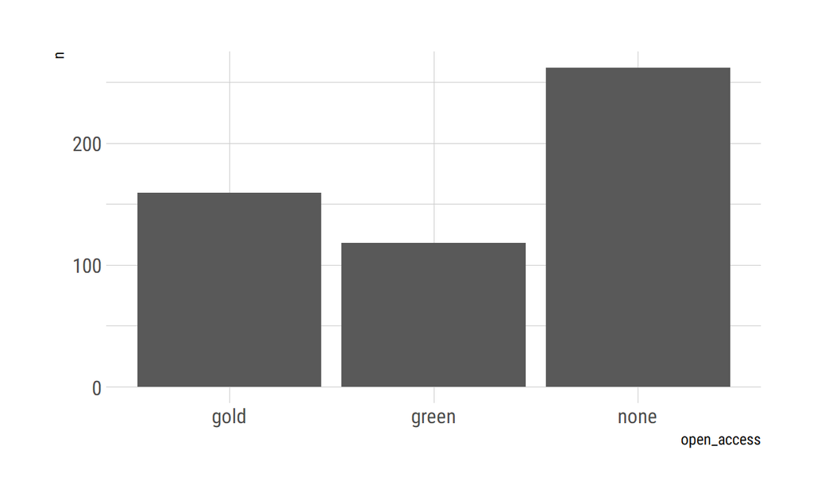

```r
# kikke på oa_status
resultater %>%
  count(open_access) %>%
  ggplot(
    aes(
      x = open_access,
      y = n
      )
    ) +
  geom_col()
```

I følge Cristin er omtrent halvparten av HVLs 2017-publikasjoner ikke åpent tilgjengelige, litt over en fjerdedel gull OA og litt under en fjerdedel grønn OA.

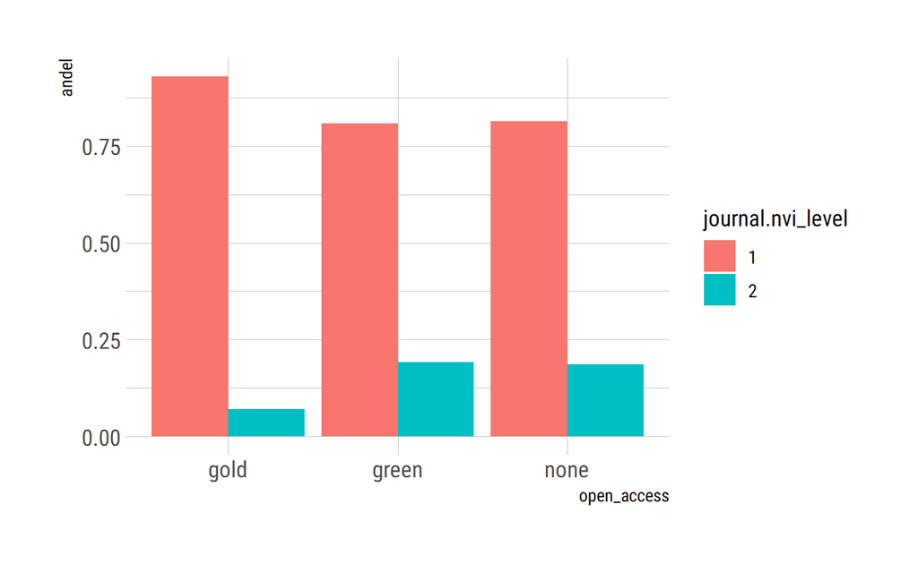

```r
# OA og tidsskrift-nivå
resultater %>%
  group_by(
    open_access,
    journal.nvi_level
    ) %>%
  filter(
    journal.nvi_level %in% c(1, 2)
    ) %>%
  summarise(
    antall = n()
    ) %>%
  mutate(
    andel = antall / sum(antall)
    ) %>%
  ggplot(
    aes(
      x = open_access,
      y = andel,
      fill = journal.nvi_level
      )
    ) +
  geom_col(position = "dodge")
```

Det er noe lavere nivå 2-andel på gull OA-publikasjonene.

## Oppdrag: finansiør og kvalitet

Vi starter med å slå sammen `results` med `funding source` fra Cristin-uttrekket, og ta bort unødvendige kolonner:

```r
#slå sammen med lenke-tabellen
cristin_funding <- resultater %>%
  select(
    cristin_result_id,
    journal.nvi_level
    ) %>%
  left_join(publikasjoner$funding_sources, by = "cristin_result_id")

cristin_funding %>%
  count(funding_source_code, sort = TRUE)
```

```
# A tibble: 37 x 2
   funding_source_code     n
   <chr>               <int>
 1 <NA>                  384
 2 NFR                   124
 3 HIB                    15
 4 UIS                    13
 5 HVE                    12
 6 HDI                     9
 7 HV                      9
 8 OTHER                   9
 9 HIOA                    4
10 HSF                     4
# ... with 27 more rows
```

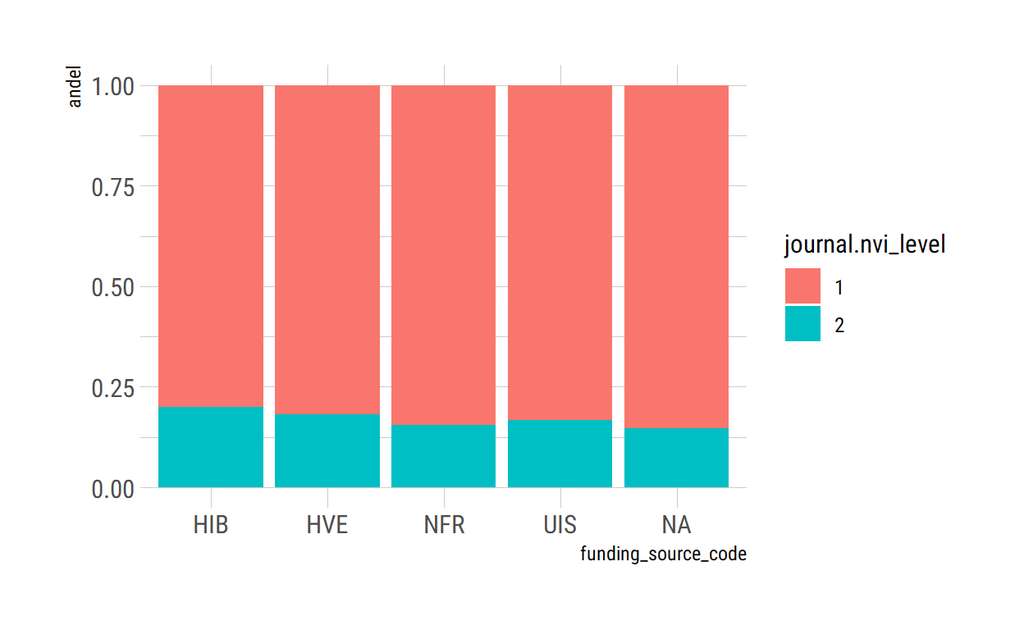

```r
cristin_funding %>%
  filter(
    journal.nvi_level %in% c(1, 2),
    funding_source_code %in% c(
      NA, "NFR", "HIB", "UIS", "HVE"
      )
    ) %>%
  group_by(funding_source_code, journal.nvi_level) %>%
  summarise(antall = n()) %>%
  mutate(andel = antall / sum(antall)) %>%
  ggplot(
    aes(x = funding_source_code,
        y = andel,
        fill = journal.nvi_level)
  ) +
  geom_col()
```